# Quora Question Pairs Similarity

# 1. Problem and Goal

## 1.1 What is Quora:

Quora is very popular plateform for learners, here we can ask question and get answers of any kind of topics. It is very usefull for knowledge purpose for students, professionals, teachers and industry leaders all keen to share their knowledge. Quora has approximatly **300 million monthly active users** of all field, Moslty everyone visits quora if they are looking for something on internet. It is one of the best social site for learners.

## 1.2 Problem statement

We asks questions on quora, two or more people may ask the same questions in different wordings, The meaning of question is same but they had used differnt sentences. For example :

- **Q1: Where can I get cheap food in Kanpur?**
- **Q2 Where are the cheap food sold in Kanpur?**
- **Q3 How can I get cheap food in kanpur?**

All the questions have same meaning but they are worded differntly. So our goal is to find duplicate questions and merge their answers so that we can get better results.

- Find and merge the questions which are already asked on quora.
- If someone asks any question, we should give them answers if that question is already answered in past.
- Aim of this project is to predict if Question1 is duplicate of Question2.

## 1.3 Useful Links for this project

Dataset is taken from https://www.kaggle.com/c/quora-question-pairs

# 2. Engineering problem

## 2.1 Know the dataset

dataset is taken from https://www.kaggle.com/c/quora-question-pairs

Data will be in a file Train.csv  
Train.csv contains 6 columns : id, qid1, qid2, question1, question2, is_duplicate  
Size of Train.csv - 60MB  
Number of rows in Train.csv = 404,290

## 2.2 Problem specification

It is a binary classification task. We have 2 possible output for is_duplicate (Yes/No).

[figure not shown]

### False Negative Rate

**Model predicted negative and it was false.**  
Our model predicted two questions are not duplicate but they are duplicate.

### False Positive Rate

**Model predicted positive and it was false.**  
Our model predicted two questions are duplicate but they are different.  
High False positive rate will affect model badly, if we will merge the answer of two different questions it we be very bad and customers will not visit this site again. We have to minimize FPR for this problem.

## 2.3 Problem Constraint

- Cost of misclassification is very high.
- We will use Log-loss as primary performance metric
- Confusion matrix will be secondary performance metric to check FPR.

# Exploratory Data Analysis

```python
import numpy as np
import pandas as pd
import matplotlib.pyplot as plt
import seaborn as sns
import warnings
warnings.filterwarnings("ignore")
```

## 3.1 Loading and Understanding dataset

```python
# Loading trainging dataset
df = pd.read_csv('Train.csv')
print("There are "+ str(df.shape[0]) + " Data points in the given training set")
print("There are "+ str(df.shape[1]) + " features in the given training set")
df.shape
```

```
There are 404290 Data points in the given training set
There are 6 features in the given training set
```

```
(404290, 6)
```

```python
df.head(8)
```

|  | id | qid1 | qid2 | question1 | question2 | is_duplicate |
| --- | --- | --- | --- | --- | --- | --- |
| 0 | 0 | 1 | 2 | What is the step by step guide to invest in sh... | What is the step by step guide to invest in sh... | 0 |
| 1 | 1 | 3 | 4 | What is the story of Kohinoor (Koh-i-Noor) Dia... | What would happen if the Indian government sto... | 0 |
| 2 | 2 | 5 | 6 | How can I increase the speed of my internet co... | How can Internet speed be increased by hacking... | 0 |
| 3 | 3 | 7 | 8 | Why am I mentally very lonely? How can I solve... | Find the remainder when [math]23^{24}[/math] i... | 0 |
| 4 | 4 | 9 | 10 | Which one dissolve in water quikly sugar, salt... | Which fish would survive in salt water? | 0 |
| 5 | 5 | 11 | 12 | Astrology: I am a Capricorn Sun Cap moon and c... | I'm a triple Capricorn (Sun, Moon and ascendan... | 1 |
| 6 | 6 | 13 | 14 | Should I buy tiago? | What keeps childern active and far from phone ... | 0 |
| 7 | 7 | 15 | 16 | How can I be a good geologist? | What should I do to be a great geologist? | 1 |

Here **id** is index of dataset(row number) and **qid1** and **qid2** is unique Question id of Question1 and Question2, **question1** and **question2** are text of given question. **is_duplicate** represent if questions are duplicate or not.

```python
df.info()
```

```
<class 'pandas.core.frame.DataFrame'>
RangeIndex: 404290 entries, 0 to 404289
Data columns (total 6 columns):
id              404290 non-null int64
qid1            404290 non-null int64
qid2            404290 non-null int64
question1       404289 non-null object
question2       404288 non-null object
is_duplicate    404290 non-null int64
dtypes: int64(4), object(2)
memory usage: 18.5+ MB
```

We have 2 NaN values in questions2 and we have 1 NaN Value for question1. We have lots of dataset we can handle missing value by dropping it.

## 3.2 Handling missing values

```python
# dropping nan will not impact our dataset because we have 404290 points and we are dropping just 3 points.
df = df.dropna()
print("There are "+ str(df.shape[0]) + " Data points in the updated training set")
print("There are "+ str(df.shape[1]) + " features in the updated training set")
df.shape
```

```
There are 404287 Data points in the updated training set
There are 6 features in the updated training set
```

```
(404287, 6)
```

## 3.3 Exploring and Visualizing given dataset

### 3.3.1 Checking if dataset is balanced or not

```python
# print(df['is_duplicate'].value_counts())
x,y = df['is_duplicate'].value_counts()
print("Similar Question pairs: ",y , "and different question pairs : ",x)
print(round(100*y/(x+y),2),"percentage questions have Duplicate ")
```

```
Similar Question pairs:  149263 and different question pairs :  255024
36.92 percentage questions have Duplicate
```

We have 255024 rows which are not duplicate (ie: is_duplicate=0) and rest 149263 points are duplicate.

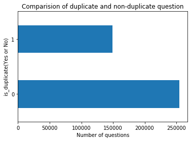

```python
df['is_duplicate'].value_counts().plot(kind='barh')
plt.title("Comparision of duplicate and non-duplicate question")
plt.xlabel("Number of questions")
plt.ylabel("is_duplicate(Yes or No)")
```

### 3.3.2 Number of unique questions

```python
# merge all the questions in pandas series
merged_q1_q2 = pd.Series(df['qid1'].tolist() + df['qid2'].tolist())
unique_questions = np.unique(merged_q1_q2)
num_unique_qs = len(unique_questions)
print("There are ",str(num_unique_qs)," unique questions in training dataset")
# if questions are repeated
num_repeated_ques = sum(merged_q1_q2.value_counts()>1)
print("There are ",str(num_repeated_ques)," unique questions that is repeated in training dataset")
print(str(round(num_repeated_ques*100/(num_unique_qs),2)),"%  unique questions that is repeated in training dataset")
print("one question has occured ",str(max(merged_q1_q2.value_counts())),' times')
```

```
There are  537929  unique questions in training dataset
There are  111778  unique questions that is repeated in training dataset
20.78 %  unique questions that is repeated in training dataset
one question has occured  157  times
```

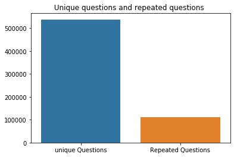

```python
x = ["unique Questions" , "Repeated Questions"]
y =  [num_unique_qs , num_repeated_ques]
plt.title (" Unique questions and repeated questions  ")
sns.barplot(x,y)
plt.show()
```

### 3.3.3 Plotting question occurance plot

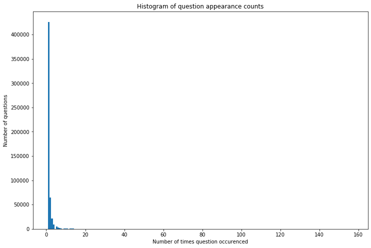

```python
plt.figure(figsize=(12,8))
plt.hist(merged_q1_q2.value_counts(),bins=200)
plt.title('Histogram of question appearance counts')
plt.xlabel('Number of times question occurenced')
plt.ylabel('Number of questions')
plt.show()
```

It is very hard to visualize the occurance relation in given scale, we have to scale down the Number of questions axis, we can use log transform here.

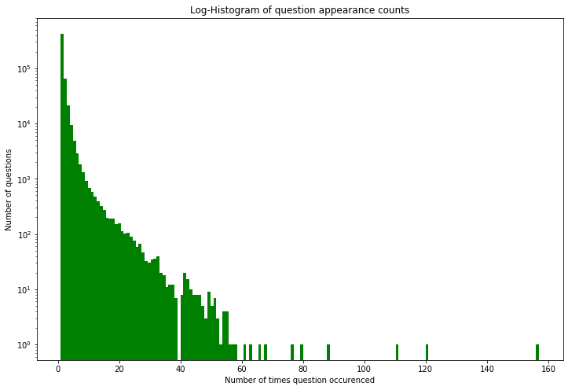

```python
plt.figure(figsize=(12,8))
plt.hist(merged_q1_q2.value_counts(),bins=160,color=['green'])
plt.yscale('log')
plt.title('Log-Histogram of question appearance counts')
plt.xlabel('Number of times question occurenced')
plt.ylabel('Number of questions')
```

## Observation

- One question has occuraced 157 time(extream right point in graph)
- Maximum question has occured once in given dataset.
- few questions have occured more than 60 times.

# Feature Engineering

## 4.1 Creating artificial Features

From domain knowledge, we can create many new features from the given dataset that may help the model to perform better.

### Observations

- If two questions are sharing common Question word (What, why, how, when,..), then there will be a higher probability that these questions will be duplicate as compared to questions having different question words.
- Number of common words may also play a role to decide if questions are duplicate or not.
- Length of questions can also play a role. so there can be many possible features. We will take a few of them and analyze.

**Here 11 new features are created using domain knowledge that can help our model to perform better**

```python
# Dataset information
df.info()
```

```
<class 'pandas.core.frame.DataFrame'>
Int64Index: 404287 entries, 0 to 404289
Data columns (total 6 columns):
id              404287 non-null int64
qid1            404287 non-null int64
qid2            404287 non-null int64
question1       404287 non-null object
question2       404287 non-null object
is_duplicate    404287 non-null int64
dtypes: int64(4), object(2)
memory usage: 21.6+ MB
```

```python
# adding the freq_qid1 = Frequency of qid1's features
df['freq_qid1'] = df.groupby('qid1')['qid1'].transform('count')
print("freq_qid1 feature will contain number of times question with qid1 have occured as question1")
df.head(1)
```

```
freq_qid1 feature will contain number of times question with qid1 have occured as question1
```

|  | id | qid1 | qid2 | question1 | question2 | is_duplicate | freq_qid1 |
| --- | --- | --- | --- | --- | --- | --- | --- |
| 0 | 0 | 1 | 2 | What is the step by step guide to invest in sh... | What is the step by step guide to invest in sh... | 0 | 1 |

```python
# adding these freq_qid2 = Frequency of qid2's features
df['freq_qid2'] = df.groupby('qid2')['qid2'].transform('count')
print("freq_qid2 feature will contain number of times question with qid2 have occured as question2")
df.head(1)
```

```
freq_qid2 feature will contain number of times question with qid2 have occured as question2
```

|  | id | qid1 | qid2 | question1 | question2 | is_duplicate | freq_qid1 | freq_qid2 |
| --- | --- | --- | --- | --- | --- | --- | --- | --- |
| 0 | 0 | 1 | 2 | What is the step by step guide to invest in sh... | What is the step by step guide to invest in sh... | 0 | 1 | 1 |

### Observation

```python
# adding q1len = Length of q1 , q2len = Length of q2 feaatues
df['q1len'] = df['question1'].str.len()
df['q2len'] = df['question2'].str.len()
df.head(1)
```

|  | id | qid1 | qid2 | question1 | question2 | is_duplicate | freq_qid1 | freq_qid2 | q1len | q2len |
| --- | --- | --- | --- | --- | --- | --- | --- | --- | --- | --- |
| 0 | 0 | 1 | 2 | What is the step by step guide to invest in sh... | What is the step by step guide to invest in sh... | 0 | 1 | 1 | 66 | 57 |

```python
# adding  q1_n_words = Number of words in Question 1
df['q1_n_words'] = df['question1'].apply(lambda x: len(x.split(" ")))
df.head(1)
```

|  | id | qid1 | qid2 | question1 | question2 | is_duplicate | freq_qid1 | freq_qid2 | q1len | q2len | q1_n_words |
| --- | --- | --- | --- | --- | --- | --- | --- | --- | --- | --- | --- |
| 0 | 0 | 1 | 2 | What is the step by step guide to invest in sh... | What is the step by step guide to invest in sh... | 0 | 1 | 1 | 66 | 57 | 14 |

```python
# adding  q2_n_words = Number of words in Question 2
df['q2_n_words'] = df['question2'].apply(lambda x: len(x.split(" ")))
df.head(1)
```

|  | id | qid1 | qid2 | question1 | question2 | is_duplicate | freq_qid1 | freq_qid2 | q1len | q2len | q1_n_words | q2_n_words |
| --- | --- | --- | --- | --- | --- | --- | --- | --- | --- | --- | --- | --- |
| 0 | 0 | 1 | 2 | What is the step by step guide to invest in sh... | What is the step by step guide to invest in sh... | 0 | 1 | 1 | 66 | 57 | 14 | 12 |

```python
# adding word common feature
def commom_word_length(row):
        words1 = set(map(lambda word: word.lower().strip(), row['question1'].split(" ")))
        words2 = set(map(lambda word: word.lower().strip(), row['question2'].split(" ")))
        return len(words1 & words2)
df['word_Common'] = df.apply(commom_word_length, axis=1)
df.head(1)
```

|  | id | qid1 | qid2 | question1 | question2 | is_duplicate | freq_qid1 | freq_qid2 | q1len | q2len | q1_n_words | q2_n_words | word_Common |
| --- | --- | --- | --- | --- | --- | --- | --- | --- | --- | --- | --- | --- | --- |
| 0 | 0 | 1 | 2 | What is the step by step guide to invest in sh... | What is the step by step guide to invest in sh... | 0 | 1 | 1 | 66 | 57 | 14 | 12 | 10 |

```python
# adding total words in both questions
def total_words(row):
    words1 = set(map(lambda x:x.lower().strip(), row['question1'].split(" ")))
    words2 = set(map(lambda x:x.lower().strip(), row['question1'].split(" ")))
    return len(words1)+len(words2)
df['total_words_in2'] = df.apply(total_words, axis =1)
df.head(1)
```

|  | id | qid1 | qid2 | question1 | question2 | is_duplicate | freq_qid1 | freq_qid2 | q1len | q2len | q1_n_words | q2_n_words | word_Common | total_words_in2 |
| --- | --- | --- | --- | --- | --- | --- | --- | --- | --- | --- | --- | --- | --- | --- |
| 0 | 0 | 1 | 2 | What is the step by step guide to invest in sh... | What is the step by step guide to invest in sh... | 0 | 1 | 1 | 66 | 57 | 14 | 12 | 10 | 24 |

```python
# word_share = (word_common)/(word_Total)
# adding word_share features
def words_share(row):
    words1 = set(map(lambda x: x.lower().strip(), row['question1'].split(" ")))
    words2 = set(map(lambda x: x.lower().strip(), row['question2'].split(" ")))
    return len(words1 & words2)/(len(words1)+len(words2))
df['words_share'] = df.apply(words_share, axis=1)
df.head(1)
```

|  | id | qid1 | qid2 | question1 | question2 | is_duplicate | freq_qid1 | freq_qid2 | q1len | q2len | q1_n_words | q2_n_words | word_Common | total_words_in2 | words_share |
| --- | --- | --- | --- | --- | --- | --- | --- | --- | --- | --- | --- | --- | --- | --- | --- |
| 0 | 0 | 1 | 2 | What is the step by step guide to invest in sh... | What is the step by step guide to invest in sh... | 0 | 1 | 1 | 66 | 57 | 14 | 12 | 10 | 24 | 0.434783 |

```python
# adding sum of frequency and absolute difference of frequency
df['freq_q1+q2'] = df['freq_qid1']+df['freq_qid2']
df['freq_q1-q2'] = abs(df['freq_qid1']-df['freq_qid2'])
df.head(1)
```

|  | id | qid1 | qid2 | question1 | question2 | is_duplicate | freq_qid1 | freq_qid2 | q1len | q2len | q1_n_words | q2_n_words | word_Common | total_words_in2 | words_share | freq_q1+q2 | freq_q1-q2 |
| --- | --- | --- | --- | --- | --- | --- | --- | --- | --- | --- | --- | --- | --- | --- | --- | --- | --- |
| 0 | 0 | 1 | 2 | What is the step by step guide to invest in sh... | What is the step by step guide to invest in sh... | 0 | 1 | 1 | 66 | 57 | 14 | 12 | 10 | 24 | 0.434783 | 2 | 0 |

All the artificial features are added.

```python
df.info()
```

```
<class 'pandas.core.frame.DataFrame'>
Int64Index: 404287 entries, 0 to 404289
Data columns (total 17 columns):
id                 404287 non-null int64
qid1               404287 non-null int64
qid2               404287 non-null int64
question1          404287 non-null object
question2          404287 non-null object
is_duplicate       404287 non-null int64
freq_qid1          404287 non-null int64
freq_qid2          404287 non-null int64
q1len              404287 non-null int64
q2len              404287 non-null int64
q1_n_words         404287 non-null int64
q2_n_words         404287 non-null int64
word_Common        404287 non-null int64
total_words_in2    404287 non-null int64
words_share        404287 non-null float64
freq_q1+q2         404287 non-null int64
freq_q1-q2         404287 non-null int64
dtypes: float64(1), int64(14), object(2)
memory usage: 55.5+ MB
```

```python
print("There are "+ str(df.shape[0]) + " Data points in the updated training set")
print("There are "+ str(df.shape[1]) + " features in the updated training set")
print('We had 6 features, we added 11 more features.')
df.shape
```

```
There are 404287 Data points in the updated training set
There are 17 features in the updated training set
We had 6 features, we added 11 more features.
```

```
(404287, 17)
```

# 4.2 Vizualization of artificial features

## 4.2.1 Vizualization of Word_share features

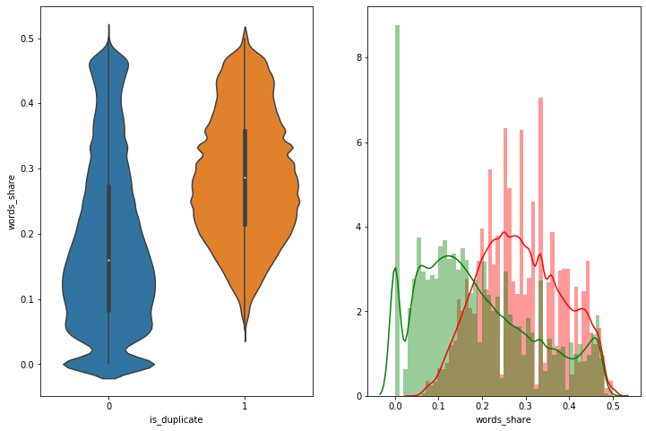

```python
plt.figure(figsize=(12, 8))
plt.subplot(1,2,1)
sns.violinplot(x = 'is_duplicate', y = 'words_share', data = df[0:])
plt.subplot(1,2,2)
sns.distplot(df[df['is_duplicate'] == 1.0]['words_share'][0:] , label = "1", color = 'red')
sns.distplot(df[df['is_duplicate'] == 0.0]['words_share'][0:] , label = "0" , color = 'green' )
plt.show()
```

# Observations

1. In violinplot, if questions are duplicate(ie. is_duplicate=1) then average word share is more as compared to non-similar questions.
2. The distributionn of words_share is highly overlapping on right side which implies there are many questions which have high word share.
3. Red cure is more towards right that is more word share, similar questions.

# 4.2.2 Vizualization of word_common features

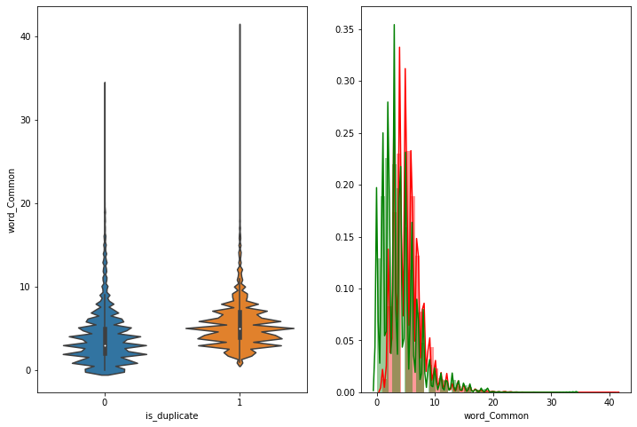

```python
plt.figure(figsize=(12,8))
plt.subplot(1,2,1)
sns.violinplot(x='is_duplicate' , y='word_Common', data=df)
plt.subplot(1,2,2)
sns.distplot(df[df['is_duplicate']==1.0]['word_Common'], label='1', color='red')
sns.distplot(df[df['is_duplicate']==0.0]['word_Common'],label='0',color='green')
plt.show()
```

# Observations

- We can see that:
  - In violinplot, if question is duplicate, average common words will be more.
  - The distributions of duplicate and non-duplicate questions are highly overlapping.

# Advance EDA

In basic Exploratory data analysis, we have analyzed the given dataset and its behaviour. There were many symbols and another form of outliers, we have to preprocess the data.

# 5.1 TEXT PREPROCESSING

- Preprocessing steps
  - HTML tag removal
  - Punctuations removal
  - Stemming (Converting words into their root words(ie: going,go,gone => 'go')
  - Stopwords removal(Stopwords don't impact our predictions very much.)
  - others

```python
from nltk.corpus import stopwords
# storing stopwords in set (search time complexity O(1))
STOPWORDS = set(stopwords.words('english'))
STOPWORDS.add("br")
STOPWORDS.add(" ")
STOPWORDS.remove("not")
STOPWORDS.remove("no")
print('-'*125)
print("There are " + str(len(STOPWORDS))+ " stopwords in the English.")
print('-'*125)
print('-'*125)
print(STOPWORDS)
print('-'*125)
```

```
-----------------------------------------------------------------------------------------------------------------------------
There are 179 stopwords in the English.
-----------------------------------------------------------------------------------------------------------------------------
-----------------------------------------------------------------------------------------------------------------------------
{'all', "needn't", 'him', 'his', 'once', 'hasn', 'shan', "weren't", 'y', 'ourselves', 'here', 'against', 'needn', 'wasn', 'which', 'itself', 'be', 'doesn', 'own', 'before', 'until', 'same', 'won', "you'll", "mightn't", "wasn't", 'yourselves', 't', 'both', 'this', 'when', 'was', 'shouldn', 'mustn', '…
-----------------------------------------------------------------------------------------------------------------------------
```

```python
# To make model robust we have to replace a few most frequestly used words into their root words
from nltk.stem import PorterStemmer
from bs4 import BeautifulSoup
import re
def preprocess_data(data):
    data = str(data).lower()
    # To make model robust we have to replace a few most frequestly used words into their root words
    data = data.replace(",000,000", "m").replace(",000", "k")\
                           .replace("won't", "will not").replace("cannot", "can not").replace("can't", "can not")\
                           .replace("n't", " not").replace("what's", "what is").replace("it's", "it is")\
                           .replace("'ve", " have").replace("i'm", "i am").replace("'re", " are")\
                           .replace("he's", "he is").replace("she's", "she is").replace("'s", " own")\
                           .replace("%", " percent ").replace("₹", " rupee ").replace("$", " dollar ")\
                           .replace("€", " euro ").replace("'ll", " will")
    data = re.sub(r"([0-9]+)000000", r"\1m", data)
    data = re.sub(r"([0-9]+)000", r"\1k", data)


    # defining porter stemmer for stemming
    porter = PorterStemmer()
    pattern = re.compile('\W')

    if type(data) == type(''):
        data = re.sub(pattern, ' ', data)


    if type(data) == type(''):
        data = porter.stem(data)
        temp = BeautifulSoup(data)
        data = temp.get_text()


    return data

# Credit :  https://medium.com/analytics-vidhya/quora-question-pairs-similarity-problem-8e3ae90441f0

preprocess_data("How can I win ₹ 1000000?")
```

```
'how can i win  rupee  1m '
```

# 5.2 Advanced Feature Extraction (FuzzyWuzzy string matching)

Definition:

- **Toekn**: Breaking sentence in different words on space (ex: "Arpit is a student" => ['Arpit','is','a','student']).
- **Stop_Word** : list most common words, which do not have much impact on model predictions.
- **Word** : List of all words which are not stopword.

Features:

### Credit

https://medium.com/analytics-vidhya/quora-question-pairs-similarity-problem-8e3ae90441f0

```python
# getting token features from questions1 and question 2
def get_token_features(x,y):
    token_features = [0.0]*10
    # we will add it into denominator to avoid ZeorDivisionError
    eps = 0.0001

    # splitting sentence into tokens
    x_tokens = x.split()
    y_tokens = y.split()

    # if any of the tokens are empty we can't draw any usefull information from these artificial featues
    if len(x_tokens)==0 or len(y_tokens)==0:
        return token_features

    # Getting set stopwords in both the questions
    x_stopwords = set([k for k in x_tokens if k in STOPWORDS])
    y_stopwords = set([k for k in x_tokens if k in STOPWORDS])

    # Getting set non-stopwords in both the questions
    x_words = set([k for k in x_tokens if k not in STOPWORDS])
    y_words = set([k for k in x_tokens if k not in STOPWORDS])

    # Getting length of common stop words
    common_stop_count = len(x_stopwords.intersection(y_stopwords))

    # Getting length of common non-stop words
    common_word_count = len(x_words.intersection(y_words))

    # Getting common tokens from questions pairs
    common_token_count = len(set(x_tokens).intersection(set(y_tokens)))

    # making featues
    token_features[0] = common_word_count / (min(len(x_words), len(y_words)) + eps)
    token_features[1] = common_word_count / (max(len(y_words), len(y_words)) + eps)
    token_features[2] = common_stop_count / (min(len(x_stopwords), len(y_stopwords)) + eps)
    token_features[3] = common_stop_count / (max(len(x_stopwords), len(y_stopwords)) + eps)
    token_features[4] = common_token_count / (min(len(x_tokens), len(y_tokens)) + eps)
    token_features[5] = common_token_count / (max(len(x_tokens), len(y_tokens)) + eps)

     # Last word of both question is same or not
    token_features[6] = int(x_tokens[-1] == y_tokens[-1])

    # First word of both question is same or not
    token_features[7] = int(x_tokens[0] == y_tokens[0])

    token_features[8] = abs(len(x_tokens) - len(y_tokens))

    #Average Token Length of both Questions
    token_features[9] = (len(x_tokens) + len(y_tokens))/2

    return token_features
```

```python
def extract_features(df):
    # preprocessing each question
    df["question1"] = df["question1"].fillna("").apply(preprocess_data)
    df["question2"] = df["question2"].fillna("").apply(preprocess_data)

    print("Adding token features")

    # Merging Features with dataset

    token_features = df.apply(lambda x: get_token_features(x["question1"], x["question2"]), axis=1)

    df["cwc_min"]       = list(map(lambda x: x[0], token_features))
    df["cwc_max"]       = list(map(lambda x: x[1], token_features))
    df["csc_min"]       = list(map(lambda x: x[2], token_features))
    df["csc_max"]       = list(map(lambda x: x[3], token_features))
    df["ctc_min"]       = list(map(lambda x: x[4], token_features))
    df["ctc_max"]       = list(map(lambda x: x[5], token_features))
    df["last_word_eq"]  = list(map(lambda x: x[6], token_features))
    df["first_word_eq"] = list(map(lambda x: x[7], token_features))
    df["abs_len_diff"]  = list(map(lambda x: x[8], token_features))
    df["mean_len"]      = list(map(lambda x: x[9], token_features))
    return df
```

```python
df = extract_features(df)
```

```
Adding token features
```

# 6 Analysis of Extracted Features

## 6.1 Plotting wordcloud

- We can observe :
  - Most frequent words of duplicate questions
  - Most frequent words of non-duplicate questions

```python
df_duplicate = df[df['is_duplicate']==1]
df_nonduplicate = df[df['is_duplicate']==0]
# converting 2d array into 1d array
p = np.dstack([df_duplicate['question1'],df_duplicate['question2']]).flatten()
n = np.dstack([df_nonduplicate['question1'],df_nonduplicate['question2']]).flatten()

print ("Number of data points in class 1 (duplicate pairs) :",len(p))
print ("Number of data points in class 0 (non duplicate pairs) :",len(n))
textp_w = " ".join(p)
textn_w = " ".join(n)
```

```
Number of data points in class 1 (duplicate pairs) : 298526
Number of data points in class 0 (non duplicate pairs) : 510048
```

```
Word Cloud for Duplicate Question pairs
```

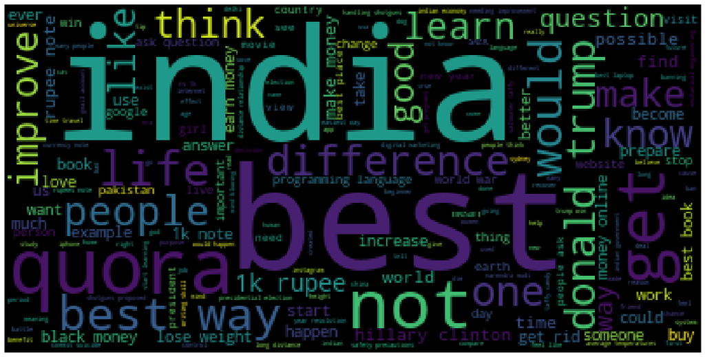

```python
from wordcloud import WordCloud
wc = WordCloud(max_words=len(textp_w), stopwords=STOPWORDS).generate(textp_w)
print ("Word Cloud for Duplicate Question pairs")
plt.figure( figsize=(20,10) )
plt.imshow(wc)
plt.axis("off")
plt.show()
```

```
Word Cloud for Duplicate Question pairs
```

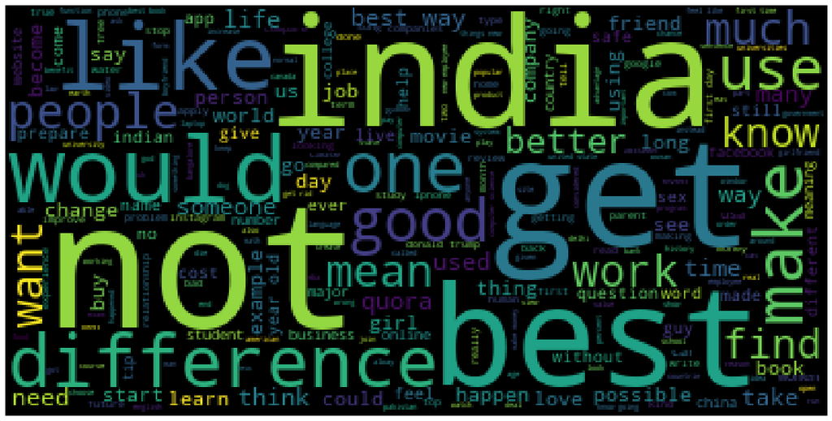

```python
from wordcloud import WordCloud
wc = WordCloud(max_words=len(textn_w), stopwords=STOPWORDS).generate(textn_w)
print ("Word Cloud for Duplicate Question pairs")
plt.figure( figsize=(20,10) )
plt.imshow(wc)
plt.axis("off")
plt.show()
```

## 6.2 Pair plot of extracted features ['ctc_min', 'cwc_min', 'csc_min','last_word_eq']

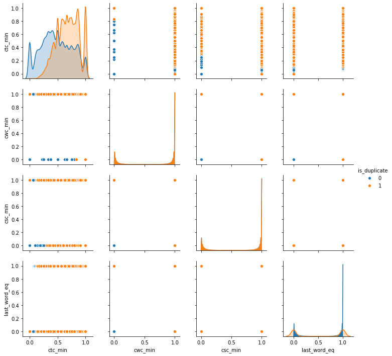

```python
n = df.shape[0]
sns.pairplot(df[['ctc_min', 'cwc_min', 'csc_min', 'last_word_eq', 'is_duplicate']][0:n], hue='is_duplicate', vars=['ctc_min', 'cwc_min', 'csc_min', 'last_word_eq'])
plt.show()
```

# Observations